讀書會共筆

# Cardiac Sarcoidosis 影像判讀

從一張 LGE 影像出發：CMR 看疤痕、PET 看活性、臨床決定意義  
結構性心臟病與介入心臟學 · 重症醫學

## THTake Home Message

Cardiac sarcoidosis (CS) 的判讀是三個層次，缺一不可：

① 先想到它  
臨床 red flag ② CMR 看疤痕  
分布型態 ③ PET 看活性  
治療決策

- **單一影像不能診斷 CS。**影像只提供「心臟受累」的證據，診斷必須回到 HRS 2014 / JCS 2016 的整體架構。
- CMR 上最有力的線索是 **non-coronary distribution** ＋ **subepicardial / mid-wall 為主、subendocardium 相對倖免**。
- **LGE 是最強的預後指標**，且 **LVEF > 35% 時仍具意義** — 這是 CS 與一般 non-ischaemic cardiomyopathy 在 ICD 決策上最大的分歧點。
- PET 的成敗取決於**飲食準備**；準備不足造成的 false positive 是臨床最常見的判讀陷阱。

## 1先看這張圖

這是 ESC Congress 現場 interactive session 的一題：*“This late enhancement is typical for…”*。現場投票 A 佔多數（48 票），但仍有 24 票選 amyloidosis、27 票選 severe multivessel CAD — 這三者的 LGE 分布其實差異很大。

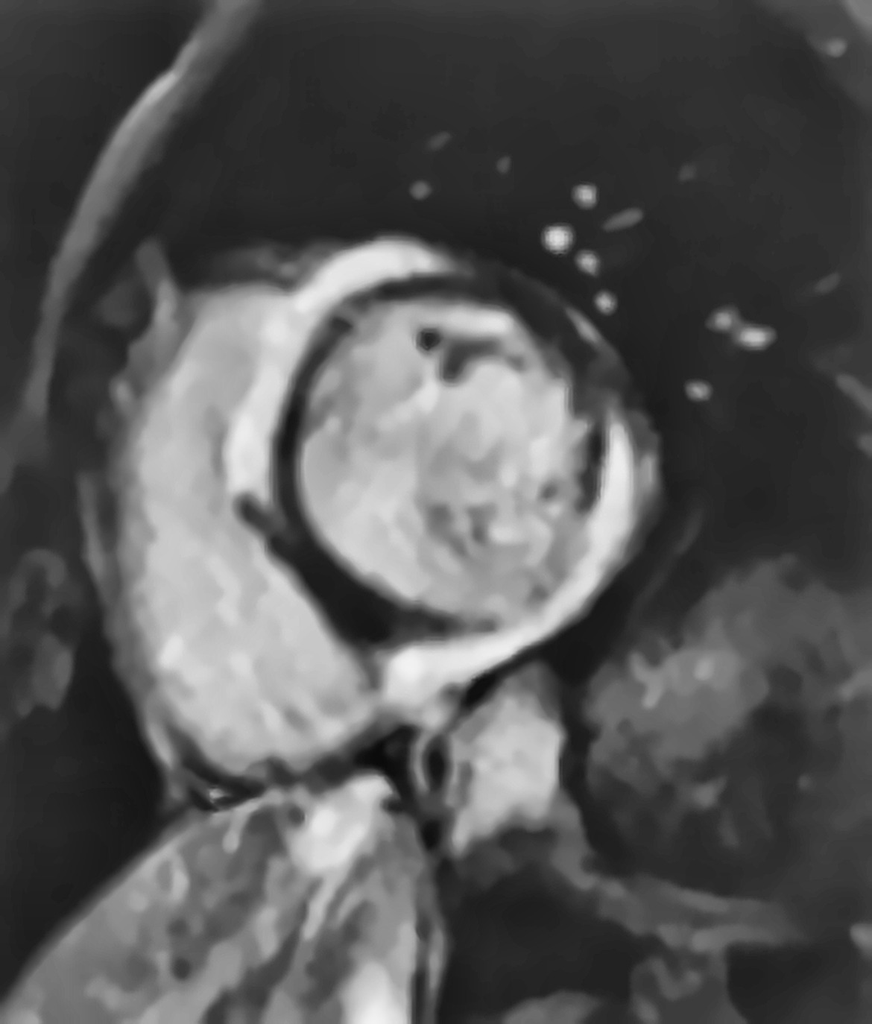

## 2四種 LGE 分布的對照

| 疾病 | 起算層次 | 分布 | 其他線索 |
| --- | --- | --- | --- |
| **Sarcoidosis** | Subepicardial / mid-wall | 斑塊狀、多灶、non-coronary，好發 basal septum 與 basal inferolateral | RV 側受累、RV insertion point「hook sign」、T2 高訊號代表活動性 |
| Amyloidosis | Subendocardial 起 | 全周性、瀰漫，常延伸為 transmural | 心肌 nulling 困難、心房壁也強化、ECV 明顯上升 |
| Ischaemic | Subendocardial 起 | 符合單一冠脈供應區、由內往外延伸 | 對應區域 wall motion 異常、可有 MVO |
| DCM | Mid-wall | 間隔中層線狀條紋 | 四腔擴大、瀰漫性收縮功能低下 |

## 3什麼時候要懷疑 CS

CS 的診斷失敗多半不是影像看錯，而是**從來沒把它放進 differential diagnosis**。以下任一項出現就該想到：

- **年齡 < 60 歲、不明原因的 high-grade AV block** — 最經典的 red flag。日本系列資料中，這類病人約 25–30% 最終證實為 cardiac sarcoidosis。
- **不明原因的 sustained ventricular tachycardia**，特別是非缺血性分布、多型態、或源自右心室。
- 無法以 CAD 解釋的 **regional wall motion abnormality**，尤其是 **basal septal thinning** 或局部 aneurysm。
- 已知 **extracardiac sarcoidosis**（肺門淋巴結、皮膚、眼、神經）出現任何心臟症狀、心電圖異常或 palpitation。
- 不明原因的 **RV dysfunction** — CS 常被誤診為 ARVC。

**臨床提醒：**年輕病人裝永久節律器之前，若 AV block 找不到原因，先做 CMR（必要時加 FDG-PET）。一旦裝了節律器再想做 CMR，流程與判讀都會複雜許多，而且可能錯過使用免疫抑制治療的時機。

## 4CMR 怎麼看

### LGE 的四個 hallmark

- **Non-coronary distribution** — 不遵循任何一條冠狀動脈的供應區。
- **Subepicardial / mid-wall 為主，subendocardial sparing** — 與 myocardial infarction 最乾淨的區分點。
- **好發部位**：basal septum 與 basal inferolateral wall；間隔的 RV 側受累、以及 RV insertion point 的「hook sign」很有提示性。
- **Patchy、multifocal、skip lesion** — 病灶之間夾雜正常心肌，這是 sarcoid 與 myocarditis 都會有的特徵，需要臨床脈絡區分。

### 其他一起看的 sequence

- **T2 / T2 mapping 高訊號** = active inflammation / oedema，代表可能有類固醇反應的空間。
- **Native T1、ECV 上升**，但呈局部而非全域均勻上升（amyloidosis 是全域性、且 blood pool nulling 困難）。
- **Basal septal thinning** 是 late-stage 表現，很容易被誤讀為 old infarct。
- Cine 上找 **局部 aneurysm 或不符合血管分布的 hypokinesia**。

**Pearl：**看到「subepicardial + 斑塊狀 + 跨血管分布」時，differential 是 sarcoidosis 與 myocarditis。分辨的關鍵不在影像本身，而在 **basal septum 受累、傳導阻滯、以及是否有心外病灶**。

## 5FDG-PET：看的是活性，不是疤痕

CMR 告訴你哪裡壞掉了；PET 告訴你現在還在不在燒。**這決定要不要給免疫抑制治療、以及治療後怎麼追蹤。**

### Dietary preparation 是成敗關鍵

- **High-fat、very-low-carbohydrate diet ≥ 24 小時**（部分中心用 12–24 小時），接著至少 **12 小時禁食**。
- 部分中心加上 **unfractionated heparin** 於顯影前施打，促進 free fatty acid 釋放。
- 目的是把**正常心肌**的 glucose uptake 壓下去，讓發炎病灶的 FDG 訊號浮出來。

### 判讀原則

- **Focal** 或 **focal-on-diffuse uptake** 才算 abnormal。
- **Diffuse homogeneous uptake** 多半代表準備失敗，不要當成陽性 — 這是最常見的 false positive 來源。
- 搭配 **rest perfusion**（NH₃ 或 rubidium）判讀疾病階段：  
  · Perfusion 正常 ＋ FDG 陽性 → early / active inflammation  
  · Perfusion 缺損 ＋ FDG 陽性 → active disease with scar  
  · Perfusion 缺損 ＋ FDG 陰性 → burnt-out fibrosis，免疫抑制治療效益低
- 治療後追蹤看 **uptake 範圍與強度的變化**，而不是單一 SUV 數值。

## 6診斷準則與臨床決策

- **HRS 2014 準則**分兩條路徑：(1) 心肌切片證實 non-caseating granuloma；或 (2) 組織證實的 extracardiac sarcoidosis ＋ 心臟受累的影像／電生理證據 ＋ 排除其他原因。
- **JCS 2016 準則**把 CMR 與 PET 的影像判讀條件寫得更細，日本臨床常用。
- **心肌切片的 sensitivity 僅約 20–30%**（病灶是 patchy 的），切片陰性**不能**排除診斷。以 electroanatomic mapping 導引切片可提高 yield。
- **ICD 決策：**CS 病人的 LGE burden 與 VT／死亡風險密切相關，且**在 LVEF > 35% 時仍具預測價值**。因此 CS 的植入考量無法直接套用一般 non-ischaemic cardiomyopathy 的 LVEF ≤ 35% 門檻；2023 年 HRS expert consensus statement 對 CS 相關心律不整的診斷與處置有專門建議。
- **免疫抑制治療**主要針對 active inflammation（PET 陽性、T2 高訊號）；已纖維化的病灶不會因治療回復。

**臨床提醒：**診斷 CS 之後，心臟不是唯一戰場。務必評估肺、眼、皮膚、神經與鈣代謝，並與胸腔科／風濕免疫科共同照護。

讀書會共筆整理人

謝慕揚 醫師 MD, PhD, FESC

結構性心臟病與介入心臟學